# An introduction to EM algorithm for Factor Analysis

Tran Le

2/12/2022

# 1 Introduction

Here is a note that I use to explore how the EM algorithm works for Factor Analysis. The R code, also, the introduction of the EM algorithm, and how it works for a Mixture of Gaussian distributions could be found [[here](https://tranktle.github.io/portfolio/2022/03/31/EM-Mixture-Gaussian.html)]

# 2 Factor Analysis

## 2.1 Introduction

- Factor analysis is used to estimate a model used to describe variance/covariance among *observed, correlated variables* by a set of *lower number* of *unobserved variables* called factors and weights.

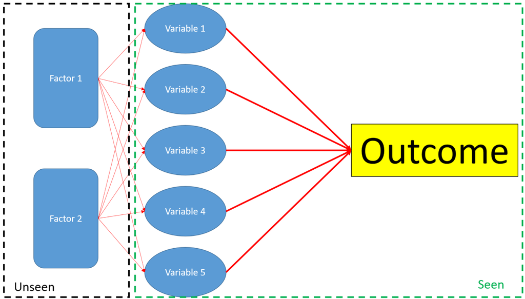

Figure 2.1: Factor Analysis. In factor analysis model, we observed the variables values but not the Factor. Figure source: https://www.lancaster.ac.uk/stor-i-student-sites/hamish-thorburn/2020/01/24/factor-analysis-and-interpretability/

- Uses:
  $$\begin{cases}
  \text{Explain the variance/covariance of variables in a simple structure}\\
  \text{Hypotheses testing}\\
  \text{Dimension reduction}
  \end{cases}$$

With this project, we focus on the parametric method that rely on the normality of the data and will use EM algorithm to solve the model.

## 2.2 Factor analysis (with Gaussian assumption) model - Frame work

Assume that we observe $n$ data points in $d$ dimension $(x_1, ..., x_n)$ where $x_i \in R^{d}, \forall i = \overline{1, n}$. The factor model postulate that $x$ is *linearly* dependent upon a *latent* variable $z \sim MVN(0, I_k)$, where $k<d$ and random noise $\epsilon \sim N(0, \Psi)$. To sum up, the frame work of factor analysis is

$$\begin{equation}
\begin{cases}
\text{latent variable: } z \sim N_k(0, I_k),\quad k<d \\
\text{random noise: } \epsilon \sim N_d(0, \Psi),\quad \Psi\in R^{d\times d}: \text{diagonal matrix} \\
\epsilon \text{ and } z \text{ are independent}\\
\text{observed variable } x = \mu + \Lambda z + \epsilon, \quad \mu\in R^d, \Lambda\in R^{d\times k} matrix
\end{cases}
\end{equation}$$

This factor model problem can be written as:

$$\begin{align}
&z \sim N_k(0, I) \\
&x|z \sim N(\mu+\Lambda z, \Psi)\\
& \text{where } z \text{ is missing information}\\
& \text{parameters of interest: } \mu\in R^{d}, \Lambda \in R^{d\times k}, \Psi \in R^{d \times d}
\end{align}$$

- *Example*: Let’s consider an example that the latent variable $z$ is in 1d and is map to $x$ in 2d

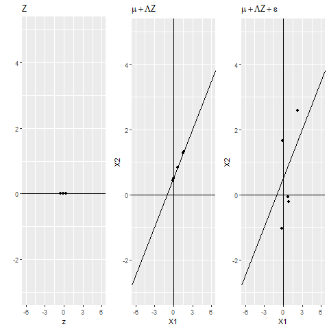

Figure 2.2: An example of the latent variable z in 1d, it is mapped to x in 2d. The fig on the left-hand side demonstrates z, the points are mapped by a linear map to 2d (in the middle fig), and then add some noises (the right-hand side fig). The problem that Factor Analysis solves is: from the observed data x that we got from the fig. on the RHS, we find the linear map and also the variance of the noise. Source: the example is coded from the idea gotten from the lecture of Dr. Andrew Ng (https://www.youtube.com/watch?v=tw6cmL5STuY)

## 2.3 Solve the problem using EM

### 2.3.1 Complete data distribution function

We have the join complete data distribution is

$$\begin{equation}
\begin{cases}
\mu_{zx} = \begin{bmatrix}
\vec{0} \\
\mu
\end{bmatrix}\\
\Sigma =
\begin{bmatrix}
\Sigma_{11}& \Sigma_{12}\\
\Sigma_{21} & \Sigma_{22}
\end{bmatrix}
=
\begin{bmatrix}
E[(z-Ez)(z-Ez)^T]& E[(z-Ez) (x-Ex)^T]\\
E[(x-Ex)(z-Ez)]& E[(x-Ex)(x-Ex)^T]
\end{bmatrix}
=
\begin{bmatrix}
I & \Lambda^T\\
\Lambda & \Lambda \Lambda^T+ \Psi
\end{bmatrix}\tag{2.2}
\end{cases}
\end{equation}$$

Proof:

- We have the $\mu_{zx}$ is computed by

$$\begin{equation*}
\begin{cases}
z \sim N(0,I) \Rightarrow \mu_z= E(z) = \vec{0}\\
x = \mu+\Lambda z+ \epsilon \Rightarrow E(x)=E(\mu+\Lambda z + \epsilon)=\mu
\end{cases}
\end{equation*}$$

### 2.3.2 Condition distribution of missing data over observed data and parameter

We have that $(z^{(s)}| x^{(s)}; \mu, \Lambda, \Psi) \sim N(\mu_{z^{(s)}| x^{(s)}}, \Sigma_{z^{(s)}| x^{(s)}})$, where

$$\begin{align}
&\mu_{z^{(s)}| x^{(s)}} = \Lambda^T(\Lambda\Lambda^T + \Psi)^{-1} (x^{(s)}-\mu)\\
&\Sigma_{z^{(s)}| x^{(s)}} = I- \Lambda^T(\Lambda\Lambda^T + \Psi)^{-1}\Lambda
\end{align}$$

Proof: The conditional distribution $(z^{(s)}| x^{(s)}; \mu, \Lambda, \Psi)$ is computed by substituting ((2.1) and ((2.2) to the conditional distribution of a Gaussian that is stated in the Appendix 4.1

### 2.3.3 M step

Here are the parameter estimators that maximize the $Q$ function

$$\begin{align*}
& \mu = \frac{\sum_{i=1}^n x^{(i)} } {n}\\
& \Lambda = \left(\sum_{i=1}^n (x^{(i)}-\mu) \mu_{z^{(i)}|x^{(i)}}^T\right) \left(\sum_{i=1}^n \mu_{z^{(i)}|x^{(i)}} \mu_{z^{(i)}|x^{(i)}}^T + \Sigma_{z^{(i)}|x^{(i)}}\right)^{-1}\\
& \phi = \frac{1}{n} \sum_{i=1}^n x^{(i)} x^{(i)^T} - x^{(i)} \mu_{z^{(i)}|x^{(i)}}^T \Lambda^T- \Lambda \mu_{z^{(i)}|x^{(i)}} x^{(i)^T} + \Lambda (\mu_{z^{(i)}|x^{(i)}} \mu_{z^{(i)}|x^{(i)}}^T + \Sigma_{z^{(i)}|x^{(i)}}) \Lambda^T\\
& \Psi_{ii} = \phi_{ii}
\end{align*}$$

The proof for this result is quite lengthy but is stated clearly in (Ng 2000). A useful trick is that might be useful is

Let’s $Q_i(z^{(i)})$ is the conditional distribution of $(z^{(s)}| x^{(s)}; \mu, \Lambda, \Psi)$, in the M step, we may need to compute $\int_{z^{(i)}}Q_i(z^{(i)}) z^{(i)} dz^{(i)}$, in fact, the answer is simple since the integral equal $E(z^{(i)})= \mu_{z^{(i)}|x^{(i)}}$

## 2.4 Pseudo-code for EM for factor analysis

1. Compute $\mu = \frac{\sum_{i=1}^n x^{(i)} } {n}$
2. Set initial $\Lambda$ and $\Psi$.  
   At each EM iteration, do
   1. Compute
      $$\begin{align*}
      &\mu_{z^{(s)}| x^{(s)}} = \Lambda^T(\Lambda\Lambda^T + \Psi)^{-1} (x^{(s)}-\mu)\\
      &\Sigma_{z^{(s)}| x^{(s)}} = I- \Lambda^T(\Lambda\Lambda^T + \Psi)^{-1}\Lambda
      \end{align*}$$
   2. Compute
      $$\begin{align*}
      & \Lambda_{(new)} = \left(\sum_{i=1}^n (x^{(i)}-\mu) \mu_{z^{(i)}|x^{(i)}}^T\right) \left(\sum_{i=1}^n \mu_{z^{(i)}|x^{(i)}} \mu_{z^{(i)}|x^{(i)}}^T + \Sigma_{z^{(i)}|x^{(i)}}\right)^{-1}\\
      & \phi_{(new)} = \frac{1}{n} \sum_{i=1}^n x^{(i)} x^{(i)^T} - x^{(i)} \mu_{z^{(i)}|x^{(i)}}^T \Lambda^T- \Lambda \mu_{z^{(i)}|x^{(i)}} x^{(i)^T} + \Lambda (\mu_{z^{(i)}|x^{(i)}} \mu_{z^{(i)}|x^{(i)}}^T + \Sigma_{z^{(i)}|x^{(i)}}) \Lambda^T\\
      & \Psi_{ii(new)} = \phi_{ii}
      \end{align*}$$
   3. Update $\Lambda$ and $\Psi$
3. Stopping criteria for (2):
- $\Vert \Lambda\Vert< \epsilon$ and $\Vert \Psi \Vert <\epsilon$

# 3 Example of EM algorithm for Factor Analysis

Let’s see how the Factor analysis performs with the introduction example (2.2 with sample size $n=500$.

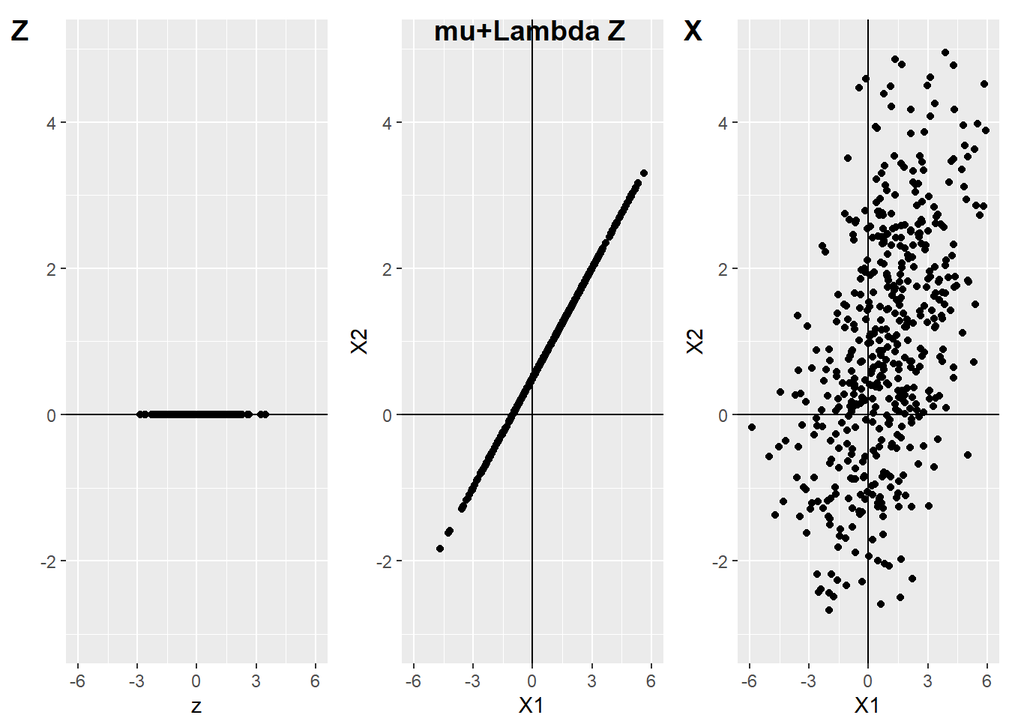

With stopping criteria $\Vert \theta\Vert < 0.0000001$, The EM converges at $i=57$

| Parameter | $\mu$ | $\Lambda$ | $\Psi$ |
| --- | --- | --- | --- |
| True Values | $\begin{bmatrix}1\\1\end{bmatrix}$ | $\begin{bmatrix}2\\1\end{bmatrix}$ | $\begin{bmatrix}1&0\\0&2\end{bmatrix}$ |
| Initial | $\text{ }$ | $\begin{bmatrix}4\\1\end{bmatrix}$ | $\begin{bmatrix}3&0\\0&2\end{bmatrix}$ |
| Predicted | $\begin{bmatrix}0.95\\ 0.99\end{bmatrix}$ | $\begin{bmatrix}1.23\\0.86\end{bmatrix}$ | $\begin{bmatrix}4.41&0\\0&3.24\end{bmatrix}$ |

With this example, the estimation for $\Lambda$ is smaller than the actual value and the estimation for the co-variance matrix $\Psi$ is bigger than the actual value.

# 4 Appendix

## 4.1 Marginals and conditionals of Gaussian

Suppose we have a vector-valued random variable

$$\begin{equation*}
\boldsymbol{x} =
\begin{bmatrix}
x_1 \\
x_2
\end{bmatrix}\text{, where} x_1 \in R^r, x_2 \in R^s, \text{ and} x \in R^{r+s}
\end{equation*}$$

Suppose $x \sim N(\mu; \Sigma)$, where

$$\begin{align*}
&\mu_{zx} = \begin{bmatrix}
\mu_1 \\
\mu_2
\end{bmatrix}, \text{ where} \mu_1 \in R^r, \mu_2 \in R^s,\\
&\Sigma =
\begin{bmatrix}
\Sigma_{11}& \Sigma_{12}\\
\Sigma_{21} & \Sigma_{22}
\end{bmatrix}
\text{, where} \Sigma_{11} \in R^{r\times r}, \Sigma_{12} \in R^{r\times s}, \Sigma_{21}=\Sigma_{12}^T, \Sigma_{22}\in R^{s\times s}
\end{align*}$$

- The marginal distribution of $x_1$ and $x_2$:
  $$\begin{align}
  x_1 \sim N(\mu_1, \Sigma_{11})\\
  x_2 \sim N(\mu_2, \Sigma_{22})\tag{4.1}
  \end{align}$$

Then we have

- The Conditional distribution of $x_1$ given $x_2$ is $x_1|x_2 \sim N(\mu_{1|2},\Sigma_{1|2})$, where

$$\begin{align}
&\mu_{1|2} = \mu_1 + \Sigma_{12}\Sigma_{22}^{-1} (x_2 -\mu_2)\\
&\Sigma_{1|2} = \Sigma_{11}-\Sigma_{12}\Sigma_{22}^{-1}\Sigma_{21}
\end{align}$$

# 5 Conclusion

Here is a note that I use to explore how the EM algorithm works for Factor Analysis. The R code, also, the introduction of the EM algorithm, and how it works for a Mixture of Gaussian distributions could be found [[here](https://tranktle.github.io/portfolio/2022/03/31/EM-Mixture-Gaussian.html)]

This project also have introduced about EM algorithm with Factor Analysis, we have observed one example when the estimation for the linear transformation matrix $\Lambda$ is smaller than the actual value and the estimation for the co-variance matrix $\Psi$ is bigger than the actual value. The article (Zhao, Yu, and Jiang 2008) and Chapter 5 of the book (McLachlan and Krishnan 2007) could be used to explore more about this problem.

# 6 References

McLachlan, Geoffrey J, and Thriyambakam Krishnan. 2007. *The EM Algorithm and Extensions*. Vol. 382. John Wiley & Sons.

Ng, Andrew. 2000. “Cs229 Lecture Notes.” *Cs229 Lecture Notes* 1 (1): 1–3.

Yang, Miin-Shen, Chien-Yo Lai, and Chih-Ying Lin. 2012. “A Robust EM Clustering Algorithm for Gaussian Mixture Models.” *Pattern Recognition* 45 (11): 3950–61.

Zhao, J-H, Philip LH Yu, and Qibao Jiang. 2008. “ML Estimation for Factor Analysis: EM or Non-EM?” *Statistics and Computing* 18 (2): 109–23.